# MUM 2024-25 Atencja (dopasowanie), przetwarzanie sekwencyjne

```python
import math
import torch
from torch import nn
from d2l import torch as d2l
import matplotlib
import numpy as np
import matplotlib.pyplot as plt
%matplotlib inline
```

[output not shown]

```python
from ipywidgets import Image
from IPython import display
animatedGif = "./ml_figures/attention-sentence.gif" #path relative to your notebook
file = open(animatedGif , "rb")
image = file.read()
progress= Image(
    value=image,
    format='gif',
    width=800,
    height=400)
display.display(progress)
```

[output not shown]

## Atencja

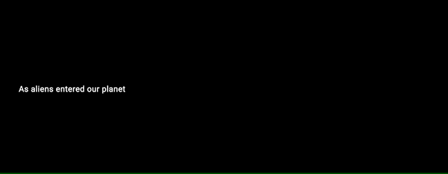

[huggingface, Michael Phi]

- Mechanizm **atencji** opisuje ważoną średnią (sekwencji) elementów z wagami, *dynamicznie* obliczanymi na podstawie konstrukcji zapytania (*query*), kluczy (*keys*) oraz wartości (*values*)
  - w transformerach będą za to odpowiedzialne "**głowy**" atencji (attention heads)
  - **query** to token reprezentujący informację, której poszukuje
  - **key** to informacja opisująca informację zawartą w tokenie, i która pasuje do zapytania query
  - **value** to właściwa informacja, która będzie znaleziona
  - atencja określa zgodność między składnikami i ich wpływem na końcowe wyjście
- średnia **nie jest** nie jest ważona *w stały sposób*
- ważenie jest uzależnione od prawdziwych aktualnych wartości a decyzja, które elementy są istotne, podejmowana jest *dynamicznie*
  - atencja jest więc dynamicznie zmienna i zależna od rzeczywistych danych, nie sposobu jej obliczania

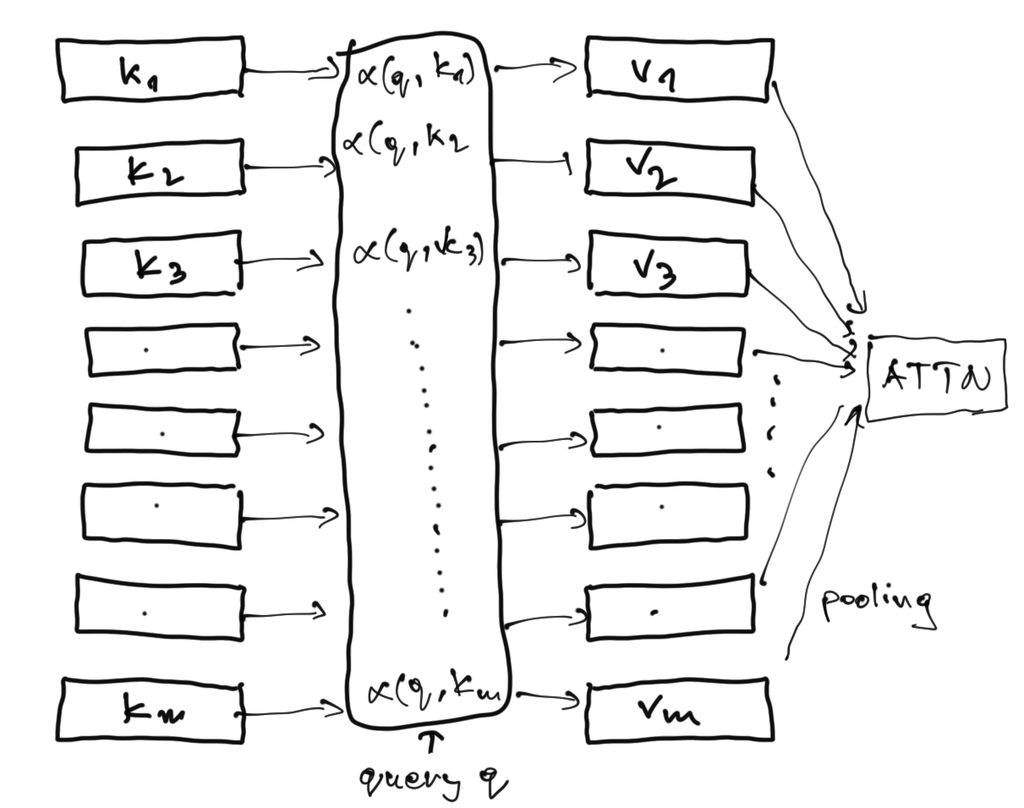

- przetwarzanie sekwencji sygnałów powoduje, że im dłuższa jest sekwencja, tym trudniej jest śledzić ważne, ale odległe, sygnały
  - przykładem przetwarzanie języka NLP, w szczególności zadanie tłumaczenia
    - angielski --> niemiecki może być bardzo trudne ze względu na różnice gramatyczne, szczególnie całkiem inny szyk zdania, słowa łączone ze sobą, etc.
  - modele rekurencyjne tworzą reprezentację całej sekwencji do aktualnego wejścia
  - atencja określa, które części sygnału są ważne w danym momencie
  - wymiennie atencję nazywamy dopasowaniem (alignment) $$Attention(q, D)=\sum_i\alpha(q, k_i)v_i$$ gdzie $D=\{(k_i,v_i)\}$ jest bazą danych, gdzie $k_i$ to klucze, $v_i$ to wartości, jak w bazie danych
    - alignment to *dopasowanie* klucza i query, także *focus*
    - $q$ jest zapytaniem (*query*)
    - $\alpha(q, k_i)\geq0$ jest wagą,
      - $\sum_i\alpha(q,k_i)=1$ zwykle przez prostą normalizację, najczęściej przez softmax, (bardziej formalnie $soft \arg\max_\beta$) $$\begin{align} \alpha_i&=\frac{\exp(f_{attn}(key_i, query))}{\sum_j\exp(f_{attn}(key_j, query))}\\ out&=\sum_i\alpha_ivalue_i \end{align}$$ gdzie $f_{attn}$ jest jakąś funkcją oceny
    - operacja ważonej sumy to *attention pooling*
  - może być więcej niż jedno query
- model atencji może być prosto zaimplementowany jako różniczkowalny
  - w procesie uczenia powstają wszystkie query, klucze, wartości
- każda waga $\alpha(q, k_i)$ odpowiada na ile klucz $k_i$ odpowiada na zapytanie *query*
  - model przy odpowiedzi może wziąć pod uwagę tylko te elementy, które mają wysoką wagę
- w sumie taki model atencji jest modelem tablicy haszujacej albo "soft"-RAM

## Jak obliczyć wartości atencji?

- wartość atencji (waga?) $\alpha(q, k_i)$ jako podobieństwo przez funkcję *odległości*, np. kernel gausowski $\alpha(q,k)=\exp\left(-\dfrac{1}{2}\|q-k\|^2\right)$
  - wtedy atencję jako gęstość $\sum_iv_i\dfrac{\alpha(q,k_i)}{\sum_j\alpha(q,k_j)}$
  - obliczeniowo złożone
- ale może prościej jako dot-product $$\alpha(q,k_i)=-\dfrac{1}{2}\|q-k_i\|^2=q^Tk_i-\dfrac{1}{2}\|k_i\|^2-\dfrac{1}{2}\|q\|^2$$
  - $\|q\|$ jest stałą i znika przy normalizacji - opuszczamy
  - $\|k_i\|^2$ jest ograniczone z góry, ma zwykle równomierny rozkład - opuszczamy
  - jeśli wektory klucza $k$ i query $q$ mają długość $d$, to funkcję wagę zdefiniować jako $a(q,k)=q^Tk/\sqrt{d}$, a samą wagę po normalizacji jako $$\alpha(q,k_1)=softmax(a(q,k_i))=\dfrac{\exp(q^Tk_i/\sqrt{d})}{\sum_j\exp(q^Tk_j/\sqrt{d})}$$ użytą w Transformerach

### skalowanie

- konieczne okazuje się **skalowanie** aby utrzymać odpowiednią wariancję po inicjalizacji
  - model jest inicjalizowany tak by utrzymać podobną wariancję we wszystkich warstwach modelu
  - jeśli query i klucze są z rozkładu normalnego, to spowoduje $$\begin{align} q_i&\sim\mathcal{N}(0,\sigma^2), k_i\sim\mathcal{N}(0,\sigma^2)\\ Var&\left(\sum_{i=1}^{d_k}q_i\cdot{}k_i\right)=\sigma^4\cdot{}d_k \end{align}$$

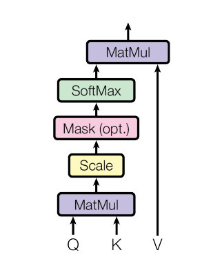

- w przetwarzaniu sekwencji będą się pojawiały kolejne stany ukryte enkodera/dekodera
  - atencje dla klucza $k_i$ trzeba będzie policzyć jako sumę dla $t$ kolejnych stanów $\sum_k^t\alpha(q,k_i)v_i$
  - dla przyspieszenia obliczeń wszystko można zdefiniować jako mnożenie macierzy $$softmax\left(\dfrac{QK^T}{\sqrt{d}}\right)V$$ dla $d$-wymiarowych
    - $n$ queries $Q\in\mathbb{R}^{n\times{}d}$
    - m kluczy $K\in\mathbb{R}^{n\times{}d}$ i wartości $V\in\mathbb{R}^{n\times{}d}$

### atencja addytywna

- jeśli queries i klucze nie mają równego wymiaru, to możliwe jest zastosowanie tzw. *addytywnej atencji*, gdzie mamy dodatkowe macierze wag $W_q$ i $W_k$ i wagę $a(q,k)=w_v\tanh(W_qq+W_kk)$
  - wszystkie macierze są parametrami modelu

## multi-head attention

- wielokrotnie potrzebna jest atencja uwzględniająca różne aspekty, gdzie *uśrednienie* nie będzie wystarczające
  - możliwy jest podział na **h** sub-queries, sub-keys, sub-values i wtedy $$\begin{align} Multihead(Q, K, V)=&Cocat(head_1,\dots,head_h)W_0\\ head_i=&Attn(QW_i^Q, KW_i^K, VW_i^V) \end{align}$$
  - każda **głowa** $h_i$ jest liniowym mapowaniem z parametrami $(W_i^Q, W_i^K, W_i^V)$
  - które są łączone i przetwarzane liniowo przez macierz $W_0$
- wielo-głowicowa atencja jest odporna na permutacje
  - jeśli jednak kolejność *jest* istotna, to konieczne będzie kodowanie pozycji

## Model Bahdanau (2014)

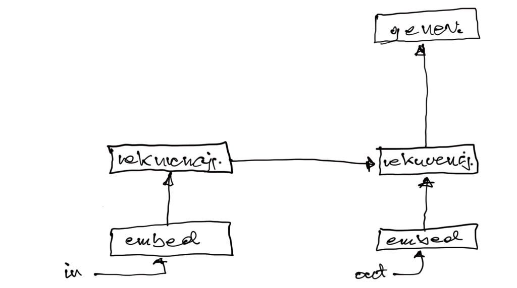

- w przetwarzaniu rekurencyjnym, np. dla NLP, korzystamy często z modelu **seq2seq** (Sutskever)
  - model składa się z dwóch sieci rekurencyjnych
    - enkodera przetwarzającego kolejne tokeny sygnału wejściowego,
    - enkoder generuje *stan ukryty*, kodujący *całą dotychczasową* sekwencję wejściową
    - stan jest przekazywany do dekodera
    - dekoder na podstawie stanu ukrytego oraz dotychczasowej sekwencji generuje sekwencję wyjściową
      - generatorem jest sieć neuronowa, chociażby tzw. *fully connected*
      - ok dla krótkich sekwencji
      - przy dłuższych model szybko "zapomina" wcześniejsze stany, które wciąż mogą być istotne, biorąc pod uwagę głównie ostatnie tokeny
        - ostatnie stany są często zupełnie nieistotne
      - problem szczególnie gdy sekwencja wyjściowa różni się w kolejności od wejściowej (angielski/niemiecki)

### model Bahdanau dla generacji sekwencji wyjściowej

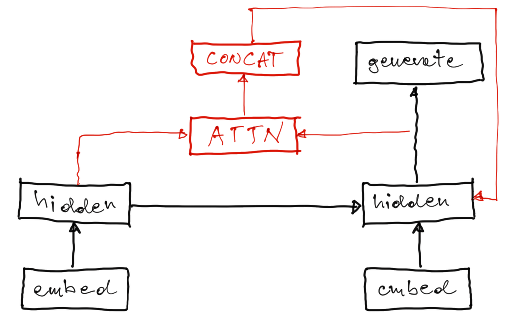

### różne modele atencji

- oparta na zawartości $score(s_t, h_i)=\cos[s_t,h_i]$
- addytywna $score(s_t, h_i)=v_a^T\tanh(W_a[s_t,h_i])$
- oparta na miejscu $\alpha_i=softmax(W_as_t)$
- ogólna $score(s_t, h_i)=s_tW_ah_i$
- iloczyn skalarny $score(s_t, h_i)=s_t^Th_i$
- skalowany iloczyn skalarny $score(s_t, h_i)=\frac{s_t^Th_i}{\sqrt{d}}$

## Wiele głów atencji (multi-head)

- ten sam proces atencji można wzmocnić
  - trójki $Q, K, V$ można *niezależnie* rzutować (liniowo) na osobne podprzestrzenie
  - dla każdego rzutowania można wyliczyć atencje *osobno* — niezależne głowy $$h_i=f(W^{(q)}_iq, W^{(k)}_ik, W^{(v)}_iv)$$ gdzie $f()$ jest funkcją poolingu
  - każda głowa pokazuje atencję dla różnych zależności, np. jak daleko wstecz spogląda
    - albo w zależności od tokena, który przetwarza
  - rzutowania są dodatkowymi parametrami modelu, które są uczone
  - wynikowe atencje są konkatenowane
- wiele głów jest potrzebne dla lepszej szybkości działania (urównoleglenie obliczeń)
  - Transformer każde rzutowanie dzieli na 8 wektorów o równej wielkości
  - aplikuje (self-)atencję o wymiarze 8-o krotnie mniejszym do każdego z wektorów
  - konkatenuje wyniki

## Self-attention

- modele rekurencyjne są jednak wciąż nieoptymalne obliczeniowo
  - mimo atencji, uczenie będzie wymagało przetwarzania wiele kroków wstecz, np. BPTT
  - wszystkie operacje wykonywane są na **sekwencjach** tokenów
- atencja w rzeczywistości może operować na **zbiorach** wektorów (tokenów)
- przetwarzanie nie musi być sekwencyjne, token po tokenie w niezmiennej kolejności
  - obraz przetwarzany na zbiór mniejszych fragmentów
    - zbiory obrazków przetwarzane na zbiory innych obrazów, np. mniejszych
    - obraz na sekwencję opisujących go tokenów (słów),
    - wyszukiwanie w obrazach interesujących nas fragmentów
- pewnym rozwiązaniem może być wykorzystanie self-attention
  - odpowiada na pytanie, w jakim stopniu elementy zbioru są do siebie podobne
  - może pozwolić na urównoleglenie obliczeń

### Self-attention

- Niech więc X będzie **zbiorem** $t$ wektorów (tokenów) $X=\{x_1,\dots,x_t\}, x_i\in\mathbb{R}^d, X\in\mathbb{R}^{t\times d}$
  - indeksy **nie** oznaczają tutaj porządku
- dla każdego wektora wyznaczamy wartość atencji $\alpha_i\geq0$ i tworzona jest reprezentacja
- $$h=\alpha_1x_1+\alpha_2x_2+\dots+\alpha_tx_t=X^Ta\in\mathbb{R}^{n}$$
  - atencja może być *miękka* pod gdy $\|a\|_1=1$
  - albo *twarda* $\|a\|_0=1$ (jak reprezentacja one-hot)
- **self-attention** (w wersji soft) policzymy więc jako $$a=soft\arg\max_\beta(Xx^T)\in\mathbb{R}^{t}$$
- w wersji **hard** jako $$a=\arg\max(Xx^T)\in\mathbb{R}^{t}$$
  - macierz atencji jest odpowiednikiem auto-korelacji macierzy $X$, stąd $A\in\mathbb{R}^{t\times t}$
  - a reprezentacja $H=A^TX\in\mathbb{R}^{t\times d}$

To tylko tytułem notacji, wymiarów, etc.

### Self-attention

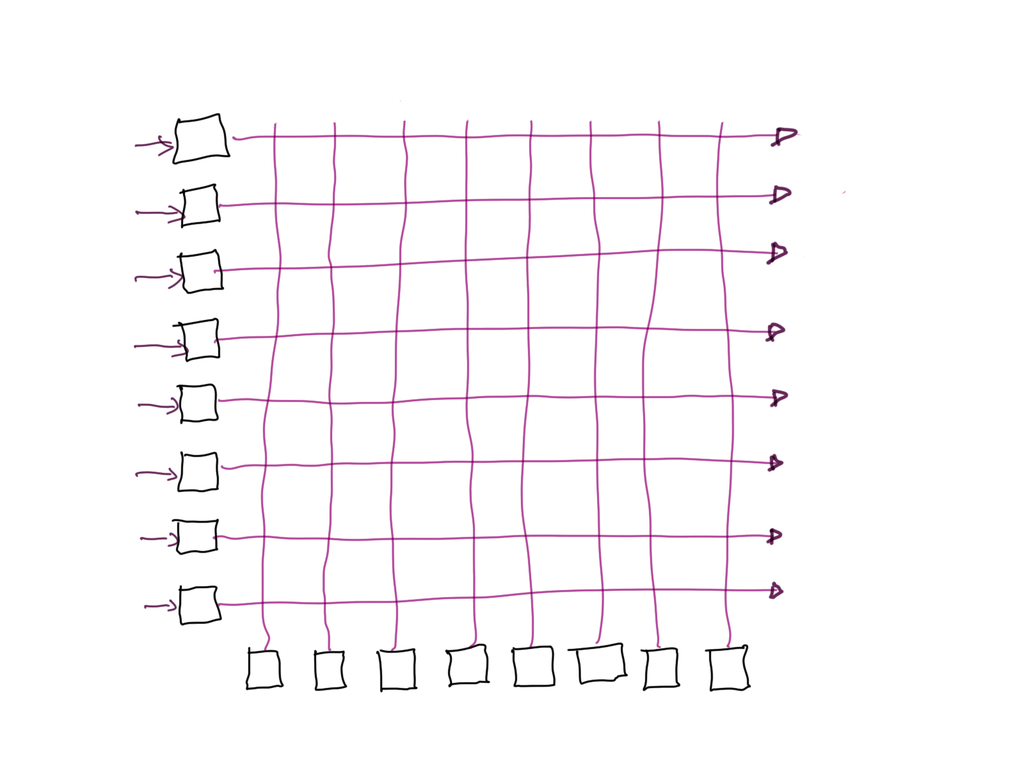

- stąd mamy
  - *queries* $q=W_qx, \in\mathbb{R}^{d}$
  - *klucze* $k=W_kx, \in\mathbb{R}^{d}$
  - *wartości* $v=W_vx, \in\mathbb{R}^{m}$
  - $Q, K, V\in\mathbb{R}^{t\times d}$, $A\in\mathbb{R}^{t\times t}$
- niech $d = m$ (chwilowo dla prostoty)
  - atencja to $$a=soft\arg\max(K^Tq)\in\mathbb{R}^{t}$$
    - znormalizowane przez $\beta=1/\sqrt{d}$ by uniezależnić wartości atencji od wymiarów wektorów, a stąd wartości wariancji
  - reprezentację $h=Va\in\mathbb{R}^{d}$, skąd $H=A^TV\in\mathbb{R}^{t\times d}$
- self-attention jest jak graf łączący się z wszystkimi tokenami, podczas gdy sieć rekurencyjna odpowiada przetwarzaniu sekwencyjnemu
  - atencja pozwala na urównoleglenia
- self-attention ma równoważność ze względu na permutację: przestawienie wejść powoduje przestawienie wyjść, ale poza tym wyjścia pozostają identyczne
  - self-attention operuje na zbiorze

### Cross-attention

- jednak liczba queries $t$ **nie musi wcale** być równa liczbie kluczy i odpowiedzi, i nie muszą być związane z $X$
- niech $q=W_qx\,\in\mathbb{R}^{d}$, $k=W_kz\,\in\mathbb{R}^{d'}$, $v=W_vz\,\in\mathbb{R}^{d'}$
- $K, V \in\mathbb{R}^{t'\times d'}$
  - gdzie (zwykle) $t'>t$
- teraz atencja $a=soft\arg\max_\beta(K^T\times q)\in\mathbb{R}^{t'}$
  - atencja odpowiada operacji query na każdym kluczu
  - reprezentacja dla tego query $h=a^TV\in\mathbb{R}^{d}$, $H=A^TV\in\mathbb{R}^{t\times d}$
    - odpowiada $t$ zapytaniom do $t'$ elementów

### Wielokrotne queries etc

- wszystkie macierze możemy połączyć $$[q, k, v]=[W_q, W_k, W_v]x$$
- rozwijając do wielu queries, można je połączyć sklejając kolejne macierzze dla kolejnych queries, kluczy i wartości $$[q^1,k^1,v^1,q^2,k^2,v^2,\dots,q^p,k^p,v^p]=[W_q^1, W_k^1, W_v^1,W_q^2,W_k^2,W_v^2,\dots,W_q^p, W_k^p, W_v^p]x$$

```python
import platform

has_gpu = torch.cuda.is_available()
has_mps = getattr(torch,'has_mps',False)

device = "mps" if getattr(torch,'has_mps', False) \
    else "gpu" if torch.cuda.is_available() else "cpu"

print(f"Python Platform: {platform.platform()}")  # Python Platform: macOS-13.3.1-arm64-arm-64bit
print(f"PyTorch Version: {torch.__version__}")  # PyTsorch Version: 2.0.1

print("GPU is", "available" if has_gpu else "NOT AVAILABLE")  # GPU is NOT AVAILABLE
print("MPS is", "AVAILABLE" if has_mps else "NOT AVAILABLE")  # MPS is AVAILABLE

print(f"Target device is {device}") #Target device is mps
```

```
Python Platform: macOS-13.5.2-arm64-arm-64bit
PyTorch Version: 2.0.1
GPU is NOT AVAILABLE
MPS is AVAILABLE
Target device is mps
```